# Mini Challenge 1 eda

Als erstes müssen alle packages eingebunden werden. Ich habe mich für die tidyverse packages entschieden, da diese einen sehr grossen Teil der explorativen Datenanalyse abdecken und auch in der Wirtschaft regen gebrauch finden.

```r
library(tidyverse) #import the dplyr package suite
```

```r
untidy_clients <- read.csv("telekom_kundenabgang.csv", stringsAsFactors = TRUE)
```

Um ein Gefühl für die Daten zu bekommen, kann die funktion str() und die summary() Funktion verwendet werden.

```r
str(untidy_clients)
```

```
'data.frame':   7049 obs. of  21 variables:
 $ customerID      : Factor w/ 7040 levels "          ","0002-ORFBO",..: 5374 3961 2565 5534 6509 6549 1004 4769 5603 4533 ...
 $ gender          : Factor w/ 2 levels "Female","Male": 1 2 2 2 1 1 2 1 1 2 ...
 $ SeniorCitizen   : int  0 0 0 0 0 0 0 0 0 0 ...
 $ Partner         : Factor w/ 2 levels "No","Yes": 2 1 1 1 1 1 1 1 2 1 ...
 $ Dependents      : Factor w/ 2 levels "No","Yes": 1 1 1 1 1 1 2 1 1 2 ...
 $ tenure          : int  1 34 2 45 2 8 22 10 28 62 ...
 $ PhoneService    : Factor w/ 2 levels "No","Yes": 1 2 2 1 2 2 2 1 2 2 ...
 $ MultipleLines   : Factor w/ 3 levels "No","No phone service",..: 2 1 1 2 1 3 3 2 3 1 ...
 $ InternetService : Factor w/ 3 levels "DSL","Fiber optic",..: 1 1 1 1 2 2 2 1 2 1 ...
 $ OnlineSecurity  : Factor w/ 3 levels "No","No internet service",..: 1 3 3 3 1 1 1 3 1 3 ...
 $ OnlineBackup    : Factor w/ 3 levels "No","No internet service",..: 3 1 3 1 1 1 3 1 1 3 ...
 $ DeviceProtection: Factor w/ 3 levels "No","No internet service",..: 1 3 1 3 1 3 1 1 3 1 ...
 $ TechSupport     : Factor w/ 3 levels "No","No internet service",..: 1 1 1 3 1 1 1 1 3 1 ...
 $ StreamingTV     : Factor w/ 3 levels "No","No internet service",..: 1 1 1 1 1 3 3 1 3 1 ...
 $ StreamingMovies : Factor w/ 3 levels "No","No internet service",..: 1 1 1 1 1 3 1 1 3 1 ...
 $ Contract        : Factor w/ 3 levels "Month-to-month",..: 1 2 1 2 1 1 1 1 1 2 ...
 $ PaperlessBilling: Factor w/ 2 levels "No","Yes": 2 1 2 1 2 2 2 1 2 1 ...
 $ PaymentMethod   : Factor w/ 4 levels "Bank transfer (automatic)",..: 3 4 4 1 3 3 2 4 3 1 ...
 $ MonthlyCharges  : num  29.9 57 53.9 42.3 70.7 ...
 $ TotalCharges    : num  29.9 1889.5 108.2 1840.8 151.7 ...
 $ Churn           : Factor w/ 2 levels "No","Yes": 1 1 2 1 2 2 1 1 2 1 ...
```

Die Summary funktion kann verwendet werden, um einen groben überblick über das gesamte Dataframe zu erhalten, zusätzlich, werden bei Numerischen werten noch statistische Eigenschaften berechnet.

```r
untidy_clients %>%
  summary()
```

```
      customerID      gender     SeniorCitizen   Partner    Dependents     tenure      PhoneService          MultipleLines
 2673-CXQEU:   4   Female:3493   Min.   :0.000   No :3647   No :4939   Min.   : 0.00   No : 682     No              :3393
 5122-CYFXA:   4   Male  :3556   1st Qu.:0.000   Yes:3402   Yes:2110   1st Qu.: 9.00   Yes:6367     No phone service: 682
 5698-BQJOH:   3                 Median :0.000                         Median :29.00                Yes             :2974
 0280-XJGEX:   2                 Mean   :0.162                         Mean   :32.35
           :   1                 3rd Qu.:0.000                         3rd Qu.:55.00
 0002-ORFBO:   1                 Max.   :1.000                         Max.   :72.00
 (Other)   :7034
    InternetService             OnlineSecurity              OnlineBackup             DeviceProtection              TechSupport
 DSL        :2424   No                 :3504   No                 :3090   No                 :3100    No                 :3476
 Fiber optic:3099   No internet service:1526   No internet service:1526   No internet service:1526    No internet service:1526
 No         :1526   Yes                :2019   Yes                :2433   Yes                :2423    Yes                :2047




              StreamingTV              StreamingMovies           Contract    PaperlessBilling                   PaymentMethod
 No                 :2810   No                 :2785   Month-to-month:3881   No :2874         Bank transfer (automatic):1545
 No internet service:1526   No internet service:1526   One year      :1473   Yes:4175         Credit card (automatic)  :1522
 Yes                :2713   Yes                :2738   Two year      :1695                    Electronic check         :2370
                                                                                              Mailed check             :1612



 MonthlyCharges    TotalCharges     Churn
 Min.   : 18.25   Min.   :  18.8   No  :5176
 1st Qu.: 35.55   1st Qu.: 401.1   Yes :1872
 Median : 70.35   Median :1396.6   NA's:   1
 Mean   : 64.78   Mean   :2282.4
 3rd Qu.: 89.85   3rd Qu.:3793.8
 Max.   :118.75   Max.   :8684.8
                  NA's   :11
```

Dabei fällt auf, dass die Spalte SeniorCizizen nur Werte zwischen 0 und 1 hat mit einem Median von 0 und einem Mean von 0.162. Daher gehe ich davon aus, dass Hier gar kein Numerischer Wert sein sollte, sondern ein Boolscher Wert resp. “Yes” oder “No”. Dies kann erreicht werden, indem die Spalte zu einem Factor gecasted wird.

```r
untidy_clients <- untidy_clients %>%
  mutate(fac_SeniorCitizen = factor(SeniorCitizen, levels=c(0,1), labels=c("No", "Yes")))
summary(untidy_clients$fac_SeniorCitizen)
```

```
  No  Yes
5907 1142
```

Weiter ist die Spalte customerID im Moment noch einen Factor. In wirklichkeit handelt es sich jedoch um einen normal String wert. Dies kann mittels as.character() geändert werden.

```r
untidy_clients <- untidy_clients %>%
  mutate(str_customerID = as.character(customerID))
summary(untidy_clients$str_customerID)
```

```
   Length     Class      Mode
     7049 character character
```

Dabei fällt auf, dass es einige customer_ID mehrmals gibt. Dublizierte Werte verändern das Datenset, da wir dies nicht wollen, werden ich mit distinct() alle Dublikate eliminieren.

```r
untidy_clients <- untidy_clients %>%
  distinct()
summary(untidy_clients)
```

```
      customerID      gender     SeniorCitizen    Partner    Dependents     tenure      PhoneService          MultipleLines
 2673-CXQEU:   4   Female:3488   Min.   :0.0000   No :3641   No :4933   Min.   : 0.00   No : 682     No              :3390
           :   1   Male  :3555   1st Qu.:0.0000   Yes:3402   Yes:2110   1st Qu.: 9.00   Yes:6361     No phone service: 682
 0002-ORFBO:   1                 Median :0.0000                         Median :29.00                Yes             :2971
 0003-MKNFE:   1                 Mean   :0.1621                         Mean   :32.37
 0004-TLHLJ:   1                 3rd Qu.:0.0000                         3rd Qu.:55.00
 0011-IGKFF:   1                 Max.   :1.0000                         Max.   :72.00
 (Other)   :7034
    InternetService             OnlineSecurity              OnlineBackup             DeviceProtection              TechSupport
 DSL        :2421   No                 :3498   No                 :3088   No                 :3095    No                 :3473
 Fiber optic:3096   No internet service:1526   No internet service:1526   No internet service:1526    No internet service:1526
 No         :1526   Yes                :2019   Yes                :2429   Yes                :2422    Yes                :2044




              StreamingTV              StreamingMovies           Contract    PaperlessBilling                   PaymentMethod
 No                 :2810   No                 :2785   Month-to-month:3875   No :2872         Bank transfer (automatic):1544
 No internet service:1526   No internet service:1526   One year      :1473   Yes:4171         Credit card (automatic)  :1522
 Yes                :2707   Yes                :2732   Two year      :1695                    Electronic check         :2365
                                                                                              Mailed check             :1612



 MonthlyCharges    TotalCharges     Churn      fac_SeniorCitizen str_customerID
 Min.   : 18.25   Min.   :  18.8   No  :5173   No :5901          Length:7043
 1st Qu.: 35.50   1st Qu.: 401.4   Yes :1869   Yes:1142          Class :character
 Median : 70.35   Median :1397.5   NA's:   1                     Mode  :character
 Mean   : 64.76   Mean   :2283.3
 3rd Qu.: 89.85   3rd Qu.:3794.7
 Max.   :118.75   Max.   :8684.8
                  NA's   :11
```

Nun hat es alle Dublikate bis auf eine ID entfernt. Bei dieser Id muss noch weiter geforscht werden. Mit filter() können alle Observationen mit dieser customer_ID angezeigt werden.

```r
untidy_clients %>%
  filter(customerID == "2673-CXQEU")
```

| customerID | gender | SeniorCitizen | Partner | Dependents | tenure | PhoneService | MultipleLines | InternetService | OnlineSecurity | OnlineBackup | DeviceProtection | TechSupport | StreamingTV | StreamingMovies | Contract | PaperlessBilling | PaymentMethod | MonthlyCharges | TotalCharges | Churn | fac_SeniorCitizen | str_customerID |
| --- | --- | --- | --- | --- | --- | --- | --- | --- | --- | --- | --- | --- | --- | --- | --- | --- | --- | --- | --- | --- | --- | --- |
| 2673-CXQEU | Female | 1 | No | No | 56 | Yes | Yes | Fiber optic | Yes | Yes | Yes | No | Yes | Yes | One year | No | Electronic check | 110.50 | 6139.5 | No | Yes | 2673-CXQEU |
| 2673-CXQEU | Female | 0 | Yes | No | 7 | Yes | No | Fiber optic | No | No | Yes | No | No | No | Month-to-month | Yes | Bank transfer (automatic) | 75.15 | 496.9 | Yes | No | 2673-CXQEU |
| 2673-CXQEU | Male | 1 | No | No | 1 | Yes | No | Fiber optic | No | No | No | Yes | No | No | Month-to-month | No | Electronic check | 74.70 | 74.7 | No | Yes | 2673-CXQEU |
| 2673-CXQEU | Female | 1 | Yes | No | 25 | Yes | No | Fiber optic | No | Yes | Yes | No | Yes | Yes | Month-to-month | Yes | Electronic check | 98.50 | 2514.5 | Yes | Yes | 2673-CXQEU |

Es scheint als während diese Beobachtungen wirklich eigenständig jedoch mit der gleichen CustomerID. Da für uns die customer_ID in der Datenanalyse keine Aussagen generieren kann, lasse ich diese 4 Beobachtungen im Dataframe.

Als Schönheitsfehler fällt noch auf, dass die Spalten nicht immer gleich bennant sind. Dies kann mittels rename() geändert werden.

```r
untidy_clients <- untidy_clients %>%
  rename(CustomerID = customerID,
         Gender = gender,
         Tenure = tenure,
         str_CustomerID = str_customerID)
summary(untidy_clients)
```

```
      CustomerID      Gender     SeniorCitizen    Partner    Dependents     Tenure      PhoneService          MultipleLines
 2673-CXQEU:   4   Female:3488   Min.   :0.0000   No :3641   No :4933   Min.   : 0.00   No : 682     No              :3390
           :   1   Male  :3555   1st Qu.:0.0000   Yes:3402   Yes:2110   1st Qu.: 9.00   Yes:6361     No phone service: 682
 0002-ORFBO:   1                 Median :0.0000                         Median :29.00                Yes             :2971
 0003-MKNFE:   1                 Mean   :0.1621                         Mean   :32.37
 0004-TLHLJ:   1                 3rd Qu.:0.0000                         3rd Qu.:55.00
 0011-IGKFF:   1                 Max.   :1.0000                         Max.   :72.00
 (Other)   :7034
    InternetService             OnlineSecurity              OnlineBackup             DeviceProtection              TechSupport
 DSL        :2421   No                 :3498   No                 :3088   No                 :3095    No                 :3473
 Fiber optic:3096   No internet service:1526   No internet service:1526   No internet service:1526    No internet service:1526
 No         :1526   Yes                :2019   Yes                :2429   Yes                :2422    Yes                :2044




              StreamingTV              StreamingMovies           Contract    PaperlessBilling                   PaymentMethod
 No                 :2810   No                 :2785   Month-to-month:3875   No :2872         Bank transfer (automatic):1544
 No internet service:1526   No internet service:1526   One year      :1473   Yes:4171         Credit card (automatic)  :1522
 Yes                :2707   Yes                :2732   Two year      :1695                    Electronic check         :2365
                                                                                              Mailed check             :1612



 MonthlyCharges    TotalCharges     Churn      fac_SeniorCitizen str_CustomerID
 Min.   : 18.25   Min.   :  18.8   No  :5173   No :5901          Length:7043
 1st Qu.: 35.50   1st Qu.: 401.4   Yes :1869   Yes:1142          Class :character
 Median : 70.35   Median :1397.5   NA's:   1                     Mode  :character
 Mean   : 64.76   Mean   :2283.3
 3rd Qu.: 89.85   3rd Qu.:3794.7
 Max.   :118.75   Max.   :8684.8
                  NA's   :11
```

In der Spalte TotalCharges gibt es Observationen ohne Werte. Um diese genauer zu untersuche wird danach gefiltert.

```r
untidy_clients %>%
  filter(is.na(TotalCharges))
```

[output not shown]

```r
untidy_clients %>%
  filter(Tenure == 0 & !is.na(TotalCharges))
```

| CustomerID | Gender | SeniorCitizen | Partner | Dependents | Tenure | PhoneService | MultipleLines | InternetService | OnlineSecurity | OnlineBackup | DeviceProtection | TechSupport | StreamingTV | StreamingMovies | Contract | PaperlessBilling | PaymentMethod | MonthlyCharges | TotalCharges | Churn | fac_SeniorCitizen | str_CustomerID |
| --- | --- | --- | --- | --- | --- | --- | --- | --- | --- | --- | --- | --- | --- | --- | --- | --- | --- | --- | --- | --- | --- | --- |

Das heisst alle mit Tenure (Laufzeit) = 0 haben noch keine Rechnung gestellt bekommen, desshalb werde ich für die N/A Werte in TotalCharges einfach 0 einfügen.

```r
untidy_clients <- untidy_clients %>%
  mutate(TotalCharges = replace(TotalCharges,is.na(TotalCharges),0))
summary(untidy_clients)
```

[output not shown]

Schlussendlich haben wir noch eine Observation welche als Churn keinen Wert hat. Da es ca. 7000 Werte sind und Churn unsere Target Variable ist, werde ich diese Observation löschen.

```r
untidy_clients <- untidy_clients %>%
  drop_na(Churn)
summary(untidy_clients)
```

[output not shown]

Nun ist sind die Daten bereinigt und wir können sie in ein neues Dataframe packen, mit welchem wir dann arbeiten können.

```r
clients <- untidy_clients %>%
  mutate(CustomerID = str_CustomerID,
         SeniorCitizen = fac_SeniorCitizen) %>%
  select(Gender,
         SeniorCitizen,
         Partner,
         Dependents,
         Tenure,
         PhoneService,
         MultipleLines,
         InternetService,
         OnlineSecurity,
         OnlineBackup,
         DeviceProtection,
         TechSupport,
         StreamingTV,
         StreamingMovies,
         Contract,
         PaperlessBilling,
         PaymentMethod,
         MonthlyCharges,
         TotalCharges,
         Churn)

summary(clients)
```

```
    Gender     SeniorCitizen Partner    Dependents     Tenure      PhoneService          MultipleLines     InternetService
 Female:3488   No :5900      No :3640   No :4932   Min.   : 0.00   No : 682     No              :3389   DSL        :2420
 Male  :3554   Yes:1142      Yes:3402   Yes:2110   1st Qu.: 9.00   Yes:6360     No phone service: 682   Fiber optic:3096
                                                   Median :29.00                Yes             :2971   No         :1526
                                                   Mean   :32.38
                                                   3rd Qu.:55.00
                                                   Max.   :72.00
             OnlineSecurity              OnlineBackup             DeviceProtection              TechSupport                StreamingTV
 No                 :3497   No                 :3088   No                 :3094    No                 :3472   No                 :2809
 No internet service:1526   No internet service:1526   No internet service:1526    No internet service:1526   No internet service:1526
 Yes                :2019   Yes                :2428   Yes                :2422    Yes                :2044   Yes                :2707



            StreamingMovies           Contract    PaperlessBilling                   PaymentMethod  MonthlyCharges    TotalCharges
 No                 :2784   Month-to-month:3874   No :2871         Bank transfer (automatic):1544   Min.   : 18.25   Min.   :   0.0
 No internet service:1526   One year      :1473   Yes:4171         Credit card (automatic)  :1522   1st Qu.: 35.50   1st Qu.: 398.7
 Yes                :2732   Two year      :1695                    Electronic check         :2365   Median : 70.35   Median :1394.8
                                                                   Mailed check             :1611   Mean   : 64.76   Mean   :2280.0
                                                                                                    3rd Qu.: 89.85   3rd Qu.:3787.9
                                                                                                    Max.   :118.75   Max.   :8684.8
 Churn
 No :5173
 Yes:1869
```

Nun analysieren wir univariante Verteilungen, Da die meisten Variablen Qualtiativ sind, machen wir aus allen quantitativen Variabeln ein Histogram mit ggplot2

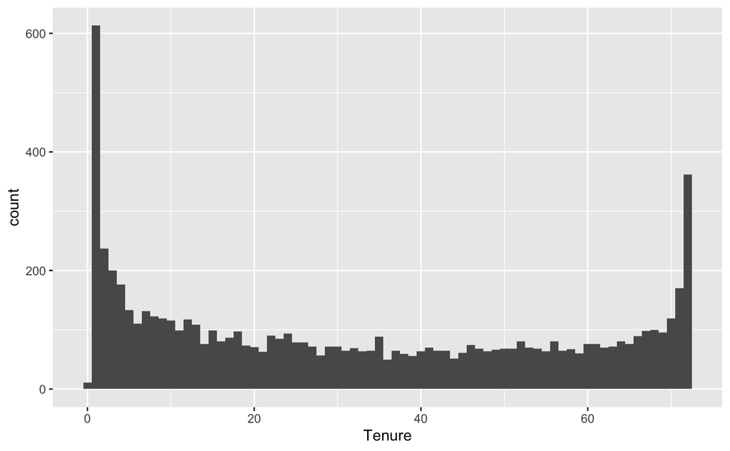

```r
ggplot(clients, aes(x = Tenure)) +
  geom_histogram(binwidth = 1)
```

Wir sehen, das die Laufzeit eine Bimodale Verteilung aufweist, mit vielen Langzeitkunden, und sehr vielen Kunden, welche schon nach einer Perdiode wieder wechseln.

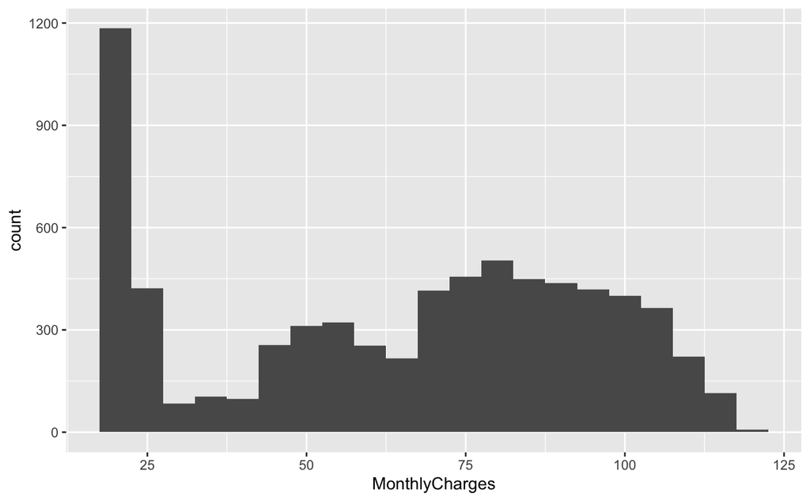

```r
ggplot(clients, aes(x = MonthlyCharges)) +
  geom_histogram(binwidth = 5)
```

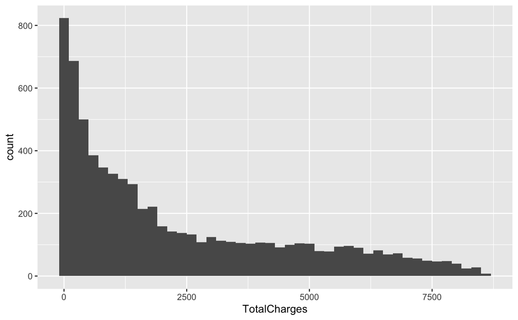

```r
ggplot(clients, aes(x = TotalCharges)) +
  geom_histogram(binwidth = 200)
```

Bei der Variable TotalCharges fällt auf, dass sie einer Exponentialvertielung ähnelt. Dies ist zurückzuführen darauf, dass viele Kunden bereits nach einer Periode den Anbieter wechseln und damit auch keine hohen Kosten haben.

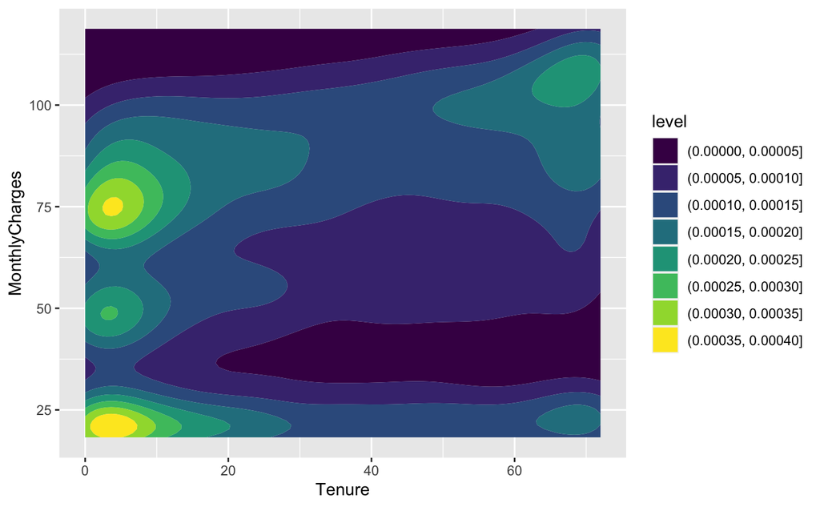

```r
ggplot(clients, aes(x = Tenure, y = MonthlyCharges)) +
  geom_density2d_filled()
```

Die zweidimensionale Verteilung der monatlichen Gebüren und der Laufzeit zeigt auf, dass die meisten Kunden welche eine Kurze Laufzeit haben, entweder einen Vertrag unter 25 Montalichen Kosten oder ca. 75 Montaliche Kosten haben.

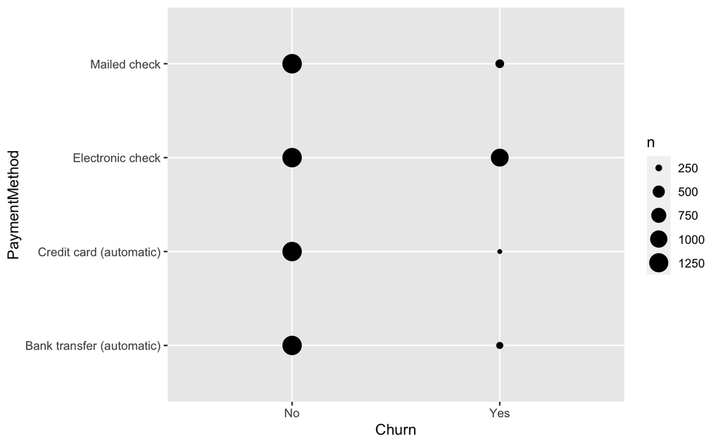

```r
ggplot(clients, aes(x = Churn, y = PaymentMethod)) +
  geom_count()
```

Hier fällt auf das die meisten abwandernden Kunden mit einem elektronischen Check bezahlen. Ob das zufällig ist oder nicht kann noch nicht beurteilt werden. Es ist auf jeden Fall eine spannende Entdeckung. Was jedoch angemerkt werden muss, ist dass die meisten Kunden via online Check bezahlen.

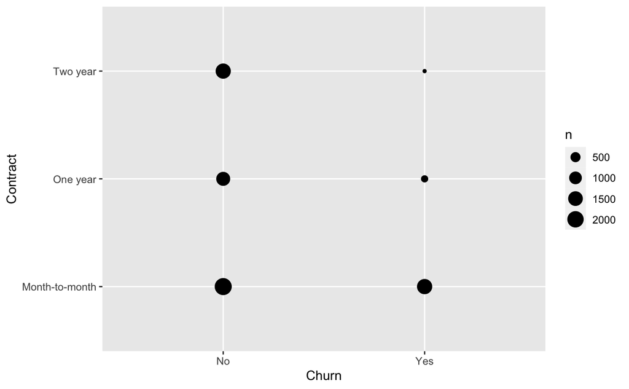

```r
ggplot(clients, aes(x = Churn, y = Contract)) +
  geom_count()
```

Auch hier spannend, dass ein grösserer Teil von Kunden abspringt, wenn sie einen Monatlichen Vertrag haben.

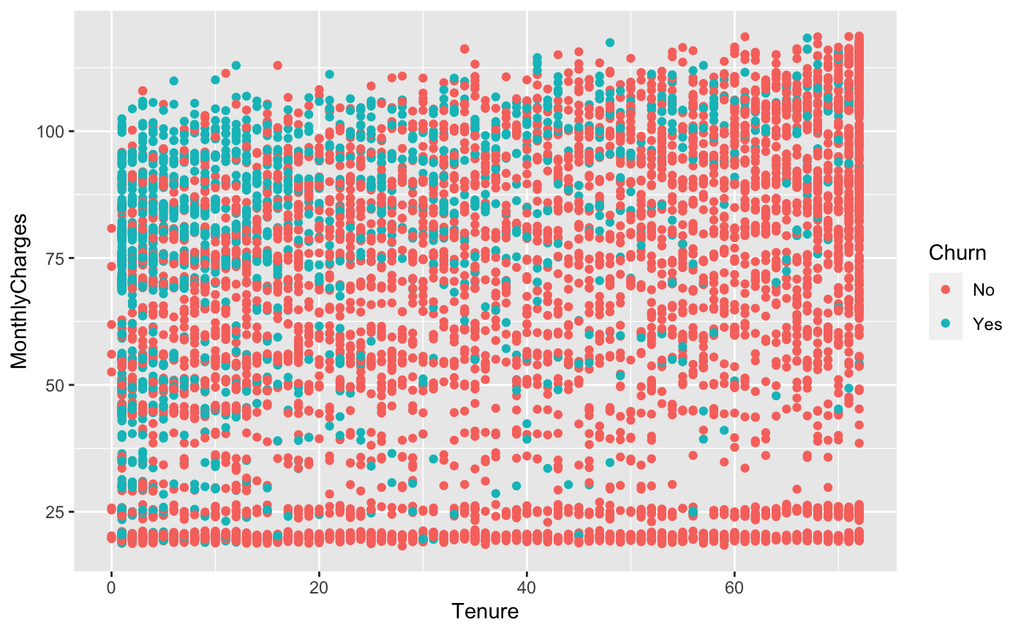

```r
ggplot(clients, aes(x = Tenure, y = MonthlyCharges, color = Churn)) +
  geom_point()
```

Hier fällt auf, dass die Kunden meist bei hohen monatlichen Kosten abspringen. Dabei sprignen die meisten eher früh ab. Es fällt auch auf, dass bei den billigeren Verträgen nur sehr vereinzelt Kunden abspringen.

Um eine differenziertere Aussage über abspringende Kunden machen zu können, werden wir einen Entscheidungsbaum generieren.

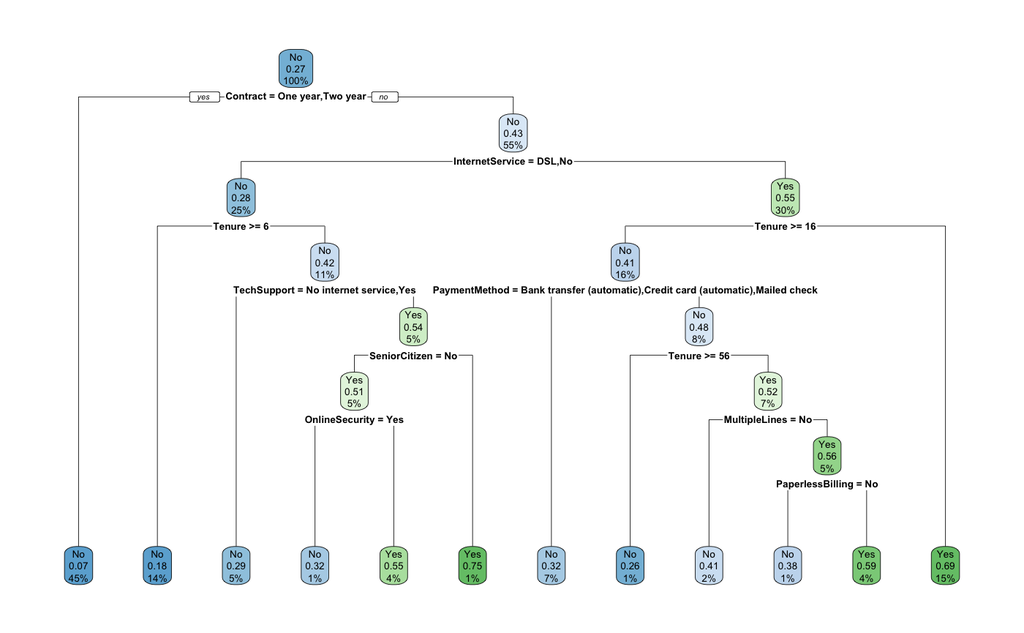

```r
library(rpart)
library(rpart.plot)

client_churn_model = rpart(Churn ~ .,
                           data = clients,
                           method = "class",
                           control = rpart.control(minsplit = 20,
                                             cp = 0.005,
                                             maxdepth = 10,))

rpart.plot(client_churn_model)
```